# The S4 Class System of Compboost

Daniel Schalk

2018-07-27

`compboost` was designed to provide a component-wise boosting framework with maximal flexibility. This document gives an introduction to the classes that must be set and how to access the data which are generated during the fitting process. In this document we are using the `C++` looking API which was generated using Eddelbuettel and François (2018) [Rcpp modules](https://cran.r-project.org/web/packages/Rcpp/vignettes/Rcpp-modules.pdf). We will have a look at:

- Define the data and factory (base-learner generators) objects.
- Define the used loss and optimizer for modeling.
- Define different logger for tracking the algorithm.
- Run the algorithm and access the fitted values.
- Continue training of the algorithm and set the algorithm to a specific iteration.

To get a deeper understanding about the functionality and how the classes are related see the [C++ documentation of the package](https://schalkdaniel.github.io/compboost/cpp_man/html/index.html).

## Data: Titanic Passenger Survival Data Set

We use the [titanic dataset](https://www.kaggle.com/c/titanic/data) with binary classification on `survived`. First of all we store the train and test data in two data frames and prevent `compboost` from crashing by removing all rows containing `NA`s:

```r
# Store train and test data:
df.train = na.omit(titanic::titanic_train)
df.test  = na.omit(titanic::titanic_test)

str(df.train)
```

```
## 'data.frame':    714 obs. of  12 variables:
##  $ PassengerId: int  1 2 3 4 5 7 8 9 10 11 ...
##  $ Survived   : int  0 1 1 1 0 0 0 1 1 1 ...
##  $ Pclass     : int  3 1 3 1 3 1 3 3 2 3 ...
##  $ Name       : chr  "Braund, Mr. Owen Harris" "Cumings, Mrs. John Bradley (Florence Briggs Thayer)" "Heikkinen, Miss. Laina" "Futrelle, Mrs. Jacques Heath (Lily May Peel)" ...
##  $ Sex        : chr  "male" "female" "female" "female" ...
##  $ Age        : num  22 38 26 35 35 54 2 27 14 4 ...
##  $ SibSp      : int  1 1 0 1 0 0 3 0 1 1 ...
##  $ Parch      : int  0 0 0 0 0 0 1 2 0 1 ...
##  $ Ticket     : chr  "A/5 21171" "PC 17599" "STON/O2. 3101282" "113803" ...
##  $ Fare       : num  7.25 71.28 7.92 53.1 8.05 ...
##  $ Cabin      : chr  "" "C85" "" "C123" ...
##  $ Embarked   : chr  "S" "C" "S" "S" ...
##  - attr(*, "na.action")=Class 'omit'  Named int [1:177] 6 18 20 27 29 30 32 33 37 43 ...
##   .. ..- attr(*, "names")= chr [1:177] "6" "18" "20" "27" ...
```

In the next step we transform the response to values $y \in \{-1, 1\}$ and do another split on the training dataset:

```r
# Response label have to be in {-1, 1}:
response = df.train$Survived * 2 - 1

# Train and evaluation split for training:
set.seed(1111)

idx.train = sample(x = seq_len(nrow(df.train)), size = 0.6 * nrow(df.train))
idx.eval  = setdiff(seq_len(nrow(df.train)), idx.train)
```

This split will be used while the training to calculate the out of bag risk.

## Data and Factories

The data classes can just handle matrices. Hence, the user is responsible for giving an appropriate data matrix to a specific base-learner. For instance the spline base-learner/factory can just handle a matrix with one column while the polynomial base-learner/factory can handle arbitrary matrices. A linear base-learner with intercept can be achieved by giving a matrix with an intercept column which contains just ones and an ordinary data column.

In `compboost` the factories accept two data object as arguments. The first one is the data source and the second one the data target (which should be an empty data object). The factory then does the following:

1. Takes the data of the data source object.
2. Transform the data depending on the base-learner (e.g. compute spline bases).
3. Write the design matrix and other permanent data into the data target object.

### Numerical Feature

We now want to include the ticket price `Fare` and the age of the passenger `Age` by using spline base-learner.

```r
# Fare:
# --------

# Define data source:
data.source.fare = InMemoryData$new(as.matrix(df.train$Fare[idx.train]), "Fare")
# Define data target:
data.target.fare = InMemoryData$new()
# Define spline factory:
spline.factory.fare = BaselearnerPSpline$new(data_source = data.source.fare,
  data_target = data.target.fare, degree = 3, n_knots = 20, penalty = 10,
  differences = 2)


# Age:
# --------

# Define data source:
data.source.age = InMemoryData$new(as.matrix(df.train$Age[idx.train]), "Age")
# Define data target:
data.target.age = InMemoryData$new()
# Define spline factory:
spline.factory.age = BaselearnerPSpline$new(data_source = data.source.age,
  data_target = data.target.age, degree = 3, n_knots = 20, penalty = 10,
  differences = 2)
```

Remember the work-flow of the factory which takes the data source, transform the data and write it into the target. We can access the transformed data of the target by calling the member function `getData()`:

```r
spline.factory.age$getData()[1:10, 1:5]
```

```
##       [,1] [,2] [,3] [,4] [,5]
##  [1,]    0    0    0    0    0
##  [2,]    0    0    0    0    0
##  [3,]    0    0    0    0    0
##  [4,]    0    0    0    0    0
##  [5,]    0    0    0    0    0
##  [6,]    0    0    0    0    0
##  [7,]    0    0    0    0    0
##  [8,]    0    0    0    0    0
##  [9,]    0    0    0    0    0
## [10,]    0    0    0    0    0
```

An idiosyncrasy of splines here is that they initialize sparse matrices by default which can be handled very well by the data object. Hence, calling `getData()` of the data target object returns an empty matrix:

```r
data.target.age$getData()
```

```
##      [,1]
## [1,]    0
```

We also want to have out of bag information while fitting the algorithm. Therefore, we have to define another data object containing the data source of the evaluation data:

```r
# Define evaluation data objects:
data.eval.fare = InMemoryData$new(as.matrix(df.train$Fare[idx.eval]), "Fare")
data.eval.age  = InMemoryData$new(as.matrix(df.train$Age[idx.eval]), "Age")
```

### Categorial Feature

Since there isn’t an automated transformation of categorical data to an appropriate matrix yet, we have to handle categorical features manually. Therefore we are just using the two feature `sex` and `Pclass`:

```r
table(df.train$Sex)
```

```
##
## female   male
##    261    453
```

```r
table(df.train$Pclass)
```

```
##
##   1   2   3
## 186 173 355
```

In component-wise boosting we use one hot encoding (dummy encoding) and give each binary vector as one source data matrix. This is done for every category of the vector. As base-learner we use a linear base-learner to estimate group specific means. The advantage of using every group as own base-learner is the possibility, that just important groups are selected. It is not necessary to update all parameters (means) of the categorical feature simultaneously. This procedure also reduces the bias of the model selection which is done inherent in component-wise boosting see (Hofner et al. 2011).

The problem now is, that we have to define a data source and target for every group within the categorical features. To avoid copy and pasting we use a for loop to dynamically store the object into a list. Note that the `S4` setting makes it more difficult to assign objects to a list. Therefore we assign an empty list before creating and storing the `S4` object:

```r
# Gender:
# --------

# Unique groups:
classes.sex = unique(df.train$Sex)

# Frame for the data and factory:
data.sex.list = list()

data.sex.list[["source"]]  = list()
data.sex.list[["target"]]  = list()
data.sex.list[["test"]]    = list()
data.sex.list[["factory"]] = list()

for (class in classes.sex) {

  # Create dummy variable and feature name:
  class.temp = ifelse(df.train$Pclass == class, 1, 0)
  data.name  = paste0("Sex.", class)

  # Define data source:
  data.sex.list[["source"]][[data.name]] = list()
  data.sex.list[["source"]][[data.name]] = InMemoryData$new(
    as.matrix(class.temp[idx.train]), # data
    data.name # data identifier
  )
  # Define data target:
  data.sex.list[["target"]][[data.name]] = list()
  data.sex.list[["target"]][[data.name]] = InMemoryData$new()

  # Define oob data for logging:
  data.sex.list[["test"]][[data.name]] = list()
  data.sex.list[["test"]][[data.name]] = InMemoryData$new(
    as.matrix(class.temp[idx.eval]), #data
    data.name # data identifier
  )

  # Define Factory object:
  data.sex.list[["factory"]][[data.name]] = list()
  data.sex.list[["factory"]][[data.name]] = BaselearnerPolynomial$new(
    data_source = data.sex.list[["source"]][[data.name]],
    data_target = data.sex.list[["target"]][[data.name]],
    degree      = 1,
    intercept   = FALSE
  )
}

# Passenger Class:
# -------------------

# Unique groups:
classes.pclass = unique(df.train$Pclass)

# Frame for the data and factory:
data.pclass.list = list()

data.pclass.list[["source"]]  = list()
data.pclass.list[["target"]]  = list()
data.pclass.list[["test"]]    = list()
data.pclass.list[["factory"]] = list()

for (class in classes.pclass) {

  # Create dummy variable and feature name:
  class.temp = ifelse(df.train$Pclass == class, 1, 0)
  data.name  = paste0("Pclass.", class)

  # Define data source:
  data.pclass.list[["source"]][[data.name]] = list()
  data.pclass.list[["source"]][[data.name]] = InMemoryData$new(
    as.matrix(class.temp[idx.train]), # data
    data.name # data identifier
  )
  # Define data target:
  data.pclass.list[["target"]][[data.name]] = list()
  data.pclass.list[["target"]][[data.name]] = InMemoryData$new()

  # Define oob data for logging:
  data.pclass.list[["test"]][[data.name]] = list()
  data.pclass.list[["test"]][[data.name]] = InMemoryData$new(
    as.matrix(class.temp[idx.eval]), # data
    data.name # data identifier
  )

  # Define Factory object:
  data.pclass.list[["factory"]][[data.name]] = list()
  data.pclass.list[["factory"]][[data.name]] = BaselearnerPolynomial$new(
    data_source = data.pclass.list[["source"]][[data.name]],
    data_target = data.pclass.list[["target"]][[data.name]],
    degree      = 1,
    intercept   = FALSE
  )
}
```

Finally we need to register all the base-learner factories we want to use for modeling:

```r
# Create new factory list:
factory.list = BlearnerFactoryList$new()

# Numeric factories:
factory.list$registerFactory(spline.factory.fare)
factory.list$registerFactory(spline.factory.age)

# Categorial features:
for (lst in data.sex.list[["factory"]]) {
  factory.list$registerFactory(lst)
}
for (lst in data.pclass.list[["factory"]]) {
  factory.list$registerFactory(lst)
}

# Print registered factories:
factory.list
```

```
##
## Registered base-learner:
##  - Age_spline_degree_3
##  - Fare_spline_degree_3
##  - Pclass.1_polynomial_degree_1
##  - Pclass.2_polynomial_degree_1
##  - Pclass.3_polynomial_degree_1
##  - Sex.female_polynomial_degree_1
##  - Sex.male_polynomial_degree_1
```

## Loss and Optimizer

Since we are interested in binary classification we can use the binomial loss. This loss is used while training and determines the pseudo residuals as well as the empirical risk which we want to minimize:

```r
loss.bin = LossBinomial$new()
loss.bin
```

```
##
## LossBinomial Loss:
##
##   Loss function: L(y,x) = log(1 + exp(-2yf(x))
##
##
```

Since we are in the boosting context the classical way of selecting the best base-learner within one iteration by using the greedy optimizer:

```r
used.optimizer = OptimizerCoordinateDescent$new()
```

## Define Logger

As mentioned above, we have to define every element of the algorithm by ourselves. This also includes the logger which also acts as stopper. That means, that we have to define the logger and if that logger should also be used as stopper.

### Iterations logger

This logger just logs the current iteration and stops if `max_iterations` is reached. In our case we want to stop after 2500 iterations:

```r
log.iterations = LoggerIteration$new(use_as_stopper = TRUE, max_iterations = 2500)
```

Note that the arguments as `max_iterations` are just used if we define the logger also as stopper. Otherwise the arguments are ignored.

### Time logger

This logger logs the elapsed time. The time unit can be one of `microseconds`, `seconds` or `minutes`. The logger stops if `max_time` is reached:

```r
log.time = LoggerTime$new(use_as_topper = FALSE, max_time = 120,
  time_unit = "seconds")
```

### Inbag risk logger

This logger logs the inbag risk by calculating the empirical risk using the training data. Note that it is necessary to specify a loss which is used to calculate the empirical risk. In the most common situation we use the the same loss as used for training to display the progress of the fitting:

```r
log.inbag = LoggerInbagRisk$new(use_as_stopper = FALSE, used_loss = loss.bin,
  eps_for_break = 0.05)
```

### Out of bag risk logger

The out of bag risk logger does basically the same as the inbag risk logger but calculates the empirical risk using another data source. Therefore, the new data object have to be a list with data sources containing the evaluation data:

```r
# List with out of bag data sources:
oob.list = list()

# Numeric featurs:
oob.list[[1]] = data.eval.fare
oob.list[[2]] = data.eval.age

# Categorial features:
for (lst in data.sex.list[["test"]]) {
  oob.list = c(oob.list, lst)
}
for (lst in data.pclass.list[["test"]]) {
  oob.list = c(oob.list, lst)
}
```

Finally we create the out of bag risk object by also specifying the corresponding `y` labels:

```r
log.oob = LoggerOobRisk$new(use_as_stopper = FALSE, used_loss = loss.bin,
  eps_for_break = 0.05, oob_data = oob.list, oob_response = response[idx.eval])
```

### Custom AUC logger

The risk logger in combination with a custom loss can also be used to log performance measures. We illustrate this procedure using the `AUC` measure from [mlr](https://mlr-org.github.io/mlr-tutorial/release/html/index.html):

```r
# Define custom "loss function"
aucLoss = function (truth, response) {
  # Convert response on f basis to probs using sigmoid:
  probs = 1 / (1 + exp(-response))

  #  Calculate AUC:
  mlr:::measureAUC(probabilities = probs, truth = truth, negative = -1, positive = 1)
}

# Define also gradient and constant initalization since they are necessary for
# the custom loss:
gradDummy = function (trutz, response) { return (NA) }
constInitDummy = function (truth, response) { return (NA) }

# Define loss:
auc.loss = LossCustom$new(aucLoss, gradDummy, constInitDummy)
```

Now we can create a new inbag and out of bag logger to log the AUC while fitting the model:

```r
log.inbag.auc = LoggerInbagRisk$new(use_as_stopper = FALSE, used_loss = auc.loss,
  eps_for_break = 0.05)
log.oob.auc   = LoggerOobRisk$new(use_as_stopper = FALSE, used_loss = auc.loss,
  eps_for_break = 0.05, oob_data = oob.list, oob_response = response[idx.eval])
```

This procedure can be used for any other risk measure. For a detailed description on how to extending `compboost` with custom losses or base-learner see the extending compboost vignette.

### Create logger list and register logger

Finally, we need to define a logger list object and register all the logger we want to track:

```r
# Define new logger list:
logger.list = LoggerList$new()

# Register logger:
logger.list$registerLogger(" iteration.logger", log.iterations)
logger.list$registerLogger("time.logger", log.time)
logger.list$registerLogger("inbag.binomial", log.inbag)
logger.list$registerLogger("oob.binomial", log.oob)
logger.list$registerLogger("inbag.auc", log.inbag.auc)
logger.list$registerLogger("oob.auc", log.oob.auc)

logger.list
```

```
##
## Registered Logger:
##  >> iteration.logger<< Logger
##  >>inbag.auc<< Logger
##  >>inbag.binomial<< Logger
##  >>oob.auc<< Logger
##  >>oob.binomial<< Logger
##  >>time.logger<< Logger
## LoggerListPrinter
```

## Train Model and Access Elements

Now after defining all object which are required by `compboost` we can define the `compboost` object with a learning rate of `0.05` and stopper rule that the algorithm should stop when the first stopper is fulfilled:

```r
# Initialize object:
cboost = Compboost_internal$new(
  response      = response[idx.train],
  learning_rate = 0.05,
  stop_if_all_stopper_fulfilled = FALSE,
  factory_list = factory.list,
  loss         = loss.bin,
  logger_list  = logger.list,
  optimizer    = used.optimizer
)

# Train the model (we want to print the trace):
cboost$train(trace = FALSE)
```

### Accessing Elements

To get the fitted parameters we can use the `getEstimatedParameter()` function:

```r
params = cboost$getEstimatedParameter()
str(params)
```

```
## List of 4
##  $ Age_spline_degree_3         : num [1:24, 1] 2.093 1.665 1.586 0.95 0.645 ...
##  $ Fare_spline_degree_3        : num [1:24, 1] -0.9038 -0.0515 0.045 -0.3911 0.3507 ...
##  $ Pclass.1_polynomial_degree_1: num [1, 1] 0.521
##  $ Pclass.3_polynomial_degree_1: num [1, 1] -1.02
```

It is also possible to get the trace how the base-learner are fitted by calling `getSelectedBaselearner()`

```r
blearner.trace = cboost$getSelectedBaselearner()
table(blearner.trace)
## blearner.trace
##          Age_spline_degree_3         Fare_spline_degree_3
##                          965                          754
## Pclass.1_polynomial_degree_1 Pclass.3_polynomial_degree_1
##                          257                          524
blearner.trace[1:10]
```

```
##  [1] "Pclass.3_polynomial_degree_1" "Pclass.3_polynomial_degree_1"
##  [3] "Pclass.3_polynomial_degree_1" "Pclass.3_polynomial_degree_1"
##  [5] "Pclass.3_polynomial_degree_1" "Fare_spline_degree_3"
##  [7] "Pclass.3_polynomial_degree_1" "Fare_spline_degree_3"
##  [9] "Fare_spline_degree_3"         "Pclass.3_polynomial_degree_1"
```

### ROC curve

We want to predict new labels for the out of bag data:

```r
# Get predicted scores and probability (with sigmoid):
scores      = cboost$predict(oob.list, response = FALSE)
prob.scores = 1 / (1 + exp(-scores))

# This can also be achieved by calling response = TRUE:
all.equal(prob.scores, cboost$predict(oob.list, response = TRUE))
```

```
## [1] TRUE
```

```r
# Calculate labels with threshold of 0.5:
pred.labels = ifelse(prob.scores > 0.5, 1, -1)

# Calculate confusion matrix:
table(pred = pred.labels, truth = response[idx.eval])
```

```
##     truth
## pred  -1   1
##   -1 144  63
##   1   13  66
```

```r
library(ggplot2)

# True labels as binary vector (0, 1):
labels = (response[idx.eval] + 1) / 2
labels = labels[order(scores, decreasing = TRUE)]
myroc = data.frame(
  TPR = cumsum(labels)/sum(labels),
  FPR = cumsum(!labels)/sum(!labels),
  Labels = labels
)

# AUC:
mlr::measureAUC(probabilities = prob.scores, truth = response[idx.eval],
  negative = -1, positive = 1)
```

```
## [1] 0.7899
```

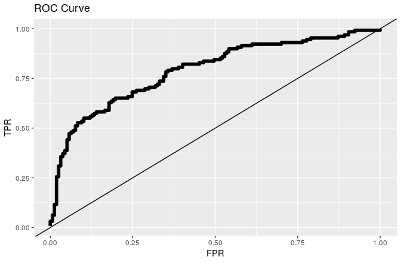

```r
ggplot(data = myroc, aes(x = FPR, y = TPR)) +
  geom_abline(intercept = 0, slope = 1) +
  geom_line(size = 2) +
  ggtitle("ROC Curve")
```

## Continue and Reposition the Training

The fastest way to continuing the training is to use the `setToIteration()` function. If we set the algorithm to an iteration bigger than the actual maximal iteration, then `compboost` automatically trains the remaining base-learner:

```r
cboost$setToIteration(k = 3000)
```

```
##
## You have already trained 2500 iterations.
## Train 500 additional iterations.
```

```r
cboost
```

```
##
## Compboost object with:
##  - Learning Rate: 0.05
##  - Are all logger used as stopper: 0
##  - Model is already trained with 3000 iterations/fitted baselearner
##  - Actual state is at iteration 3000
##  - Loss optimal initialization: -0.25
##
## To get more information check the other objects!
```

Additionally, it is possible to continuing the training using the `continueTraining()` function. This function takes a boolean to indicate if the trace should be printed and another logger list to get more control about the retraining. For instance, we can continuing the training for 3 seconds and see how far we get. We also want to reuse the out of bag logger:

```r
# Define new time logger:
new.time.logger = LoggerTime$new(use_as_stopper = TRUE, max_time = 3,
  time_unit = "seconds")

# Define new logger list and register logger:
new.logger.list = LoggerList$new()

# Define new oob logger to prevent old logger data from overwriting:
new.oob.log     = LoggerOobRisk$new(use_as_stopper = FALSE, used_loss = loss.bin,
  eps_for_break = 0.05, oob_data = oob.list, oob_response = response[idx.eval])
new.oob.auc.log = LoggerOobRisk$new(use_as_stopper = FALSE, used_loss = auc.loss,
  eps_for_break = 0.05, oob_data = oob.list, oob_response = response[idx.eval])

new.logger.list$registerLogger("time", new.time.logger)
new.logger.list$registerLogger("oob.binomial", new.oob.log)
new.logger.list$registerLogger("oob.auc", new.oob.auc.log)

# Continue training:
cboost$continueTraining(trace = FALSE, logger_list = new.logger.list)
cboost
```

```
##
## Compboost object with:
##  - Learning Rate: 0.05
##  - Are all logger used as stopper: 0
##  - Model is already trained with 12180 iterations/fitted baselearner
##  - Actual state is at iteration 12180
##  - Loss optimal initialization: -0.25
##
## To get more information check the other objects!
```

Note: With `setToIteration()` it is also possible to set `compboost` to an iteration smaller than the already trained ones. This becomes handy if one would like set the algorithm to an iteration corresponding to the minimum of the out of bag risk.

## Illustrating some Results

### Inbag vs OOB

To compare the inbag and the out of bag AUC we first have to get the logger data:

```r
cboost.log = cboost$getLoggerData()
str(cboost.log)
```

```
## List of 3
##  $ initial.training:List of 2
##   ..$ logger.names: chr [1:6] " iteration.logger" "inbag.auc" "inbag.binomial" "oob.auc" ...
##   ..$ logger.data : num [1:2500, 1:6] 1 2 3 4 5 6 7 8 9 10 ...
##  $ retraining1     :List of 2
##   ..$ logger.names: chr "setToIteration.retraining1"
##   ..$ logger.data : num [1:500, 1] 1 2 3 4 5 6 7 8 9 10 ...
##  $ retraining2     :List of 2
##   ..$ logger.names: chr [1:3] "oob.auc" "oob.binomial" "time"
##   ..$ logger.data : num [1:9180, 1:3] 0.296 0.597 0.542 0.68 0.618 ...
```

This list contains all the data collected while training and retraining. Therefore, three list elements. We are interested in the first one:

```r
cboost.log = cboost.log[[1]]
str(cboost.log)
```

```
## List of 2
##  $ logger.names: chr [1:6] " iteration.logger" "inbag.auc" "inbag.binomial" "oob.auc" ...
##  $ logger.data : num [1:2500, 1:6] 1 2 3 4 5 6 7 8 9 10 ...
```

Next we create a data frame which we use for plotting:

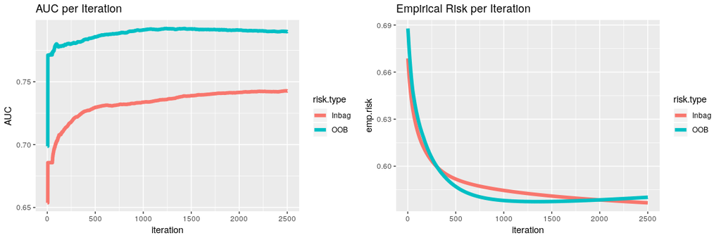

```r
auc.data = data.frame(
  iteration = rep(seq_len(nrow(cboost.log$logger.data)), 2),
  risk.type = rep(c("Inbag", "OOB"), each = nrow(cboost.log$logger.data)),
  AUC       = c(cboost.log$logger.data[, 2], cboost.log$logger.data[, 4]),
  emp.risk  = c(cboost.log$logger.data[, 3], cboost.log$logger.data[, 5])
)

p1 = ggplot(data = auc.data, aes(x = iteration, y = AUC, colour = risk.type)) +
  geom_line(size = 2) +
  ggtitle("AUC per Iteration")

p2 = ggplot(data = auc.data, aes(x = iteration, y = emp.risk, colour = risk.type)) +
  geom_line(size = 2) +
  ggtitle("Empirical Risk per Iteration")

gridExtra::grid.arrange(p1, p2, ncol = 2)
```

A surprising behavior is the AUC lines. We would expect the out of bag AUC lower than the inbag AUC which isn’t the case here. If we leave that out the curves shows the usual behavior. The out of bag curve for the AUC raises till approximately 1200 iterations and then decrease. On the other hand, the out of bag risk also falls till approximately 1200 and then starts to increase. This are clear signs that for more than 1200 iterations the algorithm starts to overfit. We should think about using the model at the 1200th iteration.

### Fare Spline Base-Learner

One of the key advantages of component-wise boosting is to have an interpretable model. For instance it is now possible to illustrate the effect of fare. Therefore, we can use the `transformData()` function of the `spline.factory.fare` object to create the spline basis for new observations:

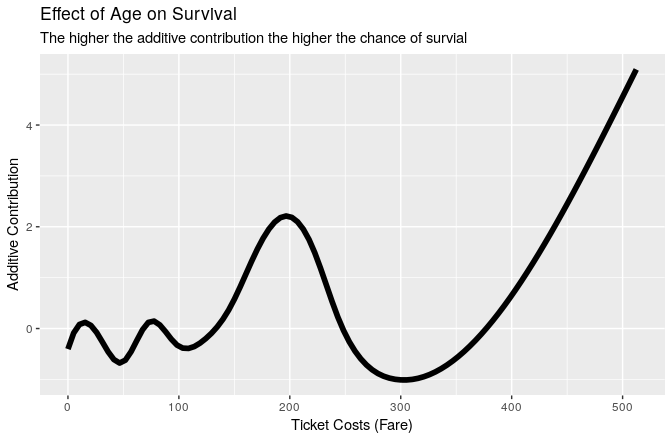

```r
params = cboost$getEstimatedParameter()
params.fare = params$Fare_spline_degree_3

x.fare  = seq(from = min(df.train$Fare), to = max(df.train$Fare), length.out = 100)
x.basis = spline.factory.fare$transformData(as.matrix(x.fare))
x.response = x.basis %*% params.fare

plot.data = data.frame(x = x.fare, y = as.numeric(x.response))

ggplot(data = plot.data, aes(x = x, y = y)) +
  geom_line(size = 2) +
  xlab("Ticket Costs (Fare)") +
  ylab("Additive Contribution") +
  labs(title="Effect of Age on Survival",
       subtitle="The higher the additive contribution the higher the chance of survial")
```

We recognize, that this curve results from taking the parameter after 12180 iterations. That could be way too much and could tend to overfitting. Because of the out of bag behavior, we set the iteration to 1200:

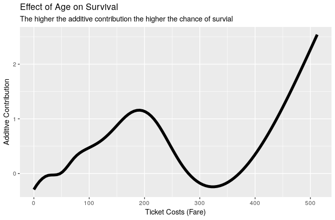

```r
cboost$setToIteration(k = 1200)

params = cboost$getEstimatedParameter()
params.fare = params$Fare_spline_degree_3

x.fare  = seq(from = min(df.train$Fare), to = max(df.train$Fare), length.out = 100)
x.basis = spline.factory.fare$transformData(as.matrix(x.fare))
x.response = x.basis %*% params.fare

plot.data = data.frame(x = x.fare, y = as.numeric(x.response))

ggplot(data = plot.data, aes(x = x, y = y)) +
  geom_line(size = 2) +
  xlab("Ticket Costs (Fare)") +
  ylab("Additive Contribution") +
  labs(title="Effect of Age on Survival",
       subtitle="The higher the additive contribution the higher the chance of survial")
```

Finally we want to get an idea on how the curve evolves over the iterations. Therefore we can use [ImageMagick](https://www.imagemagick.org/script/index.php) to create a `gif`. The approach is to get the parameter matrix by `getParameterMatrix()`, then select for the spline base-learner corresponding to `Fare` and create the `gif`:

```r
param.mat = cboost$getParameterMatrix()
idx.fare = cboost$getSelectedBaselearner() == "Fare: spline with degree 3"
sum(idx.fare)
```

```
## [1] 0
```

Now we create a new directory to store the single frames and create the `gif` using `ImageMagick`:

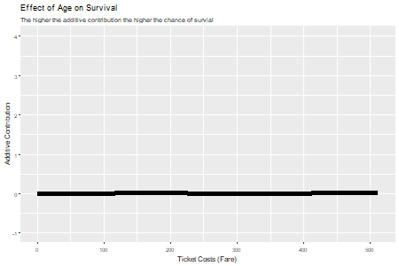

```r
idx.fare  = which(idx.fare)

# Get index of parameter corresponding to fare spline learner:
param.idx = grepl(pattern = "Fare", x = param.mat$parameter.names)

# Create new directory for the frames
dir.create("frames")

for (i in seq_along(idx.fare)){

  # Get parameter of i-th iteration
  params.fare = param.mat$parameter.matrix[idx.fare[i], param.idx]

  # Compute response for every iteration
  x.response = x.basis %*% params.fare

  plot.data = data.frame(x = x.fare, y = as.numeric(x.response))

  # Create plot:
  ggplot(data = plot.data, aes(x = x, y = y)) +
    geom_line(size = 2) +
    xlab("Ticket Costs (Fare)") +
    ylab("Additive Contribution") +
    ylim(-1, 4) +
    labs(title="Effect of Age on Survival",
         subtitle="The higher the additive contribution the higher the chance of survial")

  # Save ggplot:
  ggsave(paste0("frames/frame", stringr::str_pad(i, 4, pad = "0"), ".png"),
    width = 9, height = 6, dpi = 50)
}


# Convert the frames to gif:
system("magick -delay 1 frames/*.png frames/fare_spline.gif")

# Remove all created pngs:
file.remove(paste0("frames/", list.files(path = "frames", pattern = ".png")))
```

Note that the name of the executable of `ImageMagick` differs between the OS. On Windows we need `magick` while on Linux we have to use `convert`.

## Some Remarks

- We know that define everything using the `C++` class style is very odd, but it reflects best the underlying `C++` class system. Additionally, using the class system gives the user maximal flexibility and control about the algorithm. An `R` API which looks more familiar to the most users is in progress and one of the most important next task.
- All the sample analyses we have made here are just to give an idea how `compboost` can be used to train a component-wise boosting model and how to access the data which are gained while the fitting process.
- Since `compboost` is in an very early stage, the functionality isn’t very comprehensive. For instance there is just one optimizer at the moment and one loss class for binary classification. There is also no multi-class support at the moment.
- If someone wants to use a custom loss or base-learner we have implemented ways to extend compboost without recompiling the `C++` code. Therefore see the extending compboost vignette.

## References

Eddelbuettel, Dirk, and Romain François. 2018. “Exposing C++ Functions and Classes with Rcpp Modules.” *Vignette Included in R Package Rcpp, URL Http://CRAN. R-Project. Org/Package= Rcpp*. Citeseer.

Hofner, Benjamin, Torsten Hothorn, Thomas Kneib, and Matthias Schmid. 2011. “A Framework for Unbiased Model Selection Based on Boosting.” *Journal of Computational and Graphical Statistics* 20 (4). Taylor & Francis: 956–71.